# HW1

Ali Bahkali

2024-02-09

# Preliminary set-ups

This first section is to install and set up the list of packages needed for this lab:

```r
# List of packages that are possibly needed for the analysis and formatting in this lab:
myPackages <- c("lme4", "rsq", "MuMIn", "optimx", "MASS", "dplyr", "ggplot2",
                "HLMdiag", "lmtest", "lmerTest", "psy", "PowerUpR","nlme", "MVN",
                "skimr", "tidyverse", "pacman", "lavaan", "semTools", "gsl")

# then check if all the needed packages are installed by checking against the list
# of already installed packages in R:
installed <- sapply(myPackages, function(p) p %in% rownames(installed.packages()))

# and install any missing packages:
if (any(!installed)) {
  install.packages(myPackages[!installed])
}

# then initiate the packages management library:
library(pacman)

# to load the rest of the needed libraries in this lab at once:
p_load(lme4, rsq, MuMIn, optimx, MASS, dplyr, ggplot2, HLMdiag, lmtest, lmerTest,
       psy, PowerUpR, nlme, MVN, skimr, tidyverse, lavaan, semTools, gsl)
```

Then data loading, cleaning, and preparation for the analysis:

```r
# Data loading:
PISA09.PathAnalysis <-
  read.csv("https://raw.githubusercontent.com/alibahkali/EDPSY960/main/PISA09.PathAnalysis.csv")

# since the data has missing values (9999), we need to clean them list-wise by
# looping through each column in the data frame to convert missing values into NAs
for(col in names(PISA09.PathAnalysis)) {
  PISA09.PathAnalysis[[col]][PISA09.PathAnalysis[[col]] == 9999] <- NA
}

skim(PISA09.PathAnalysis)
```

Data summary

| Name | PISA09.PathAnalysis |
| --- | --- |
| Number of rows | 5233 |
| Number of columns | 7 |
| _______________________ |  |
| Column type frequency: |  |
| numeric | 7 |
| ________________________ |  |
| Group variables | None |

**Variable type: numeric**

| skim_variable | n_missing | complete_rate | mean | sd | p0 | p25 | p50 | p75 | p100 | hist |
| --- | --- | --- | --- | --- | --- | --- | --- | --- | --- | --- |
| CSTRAT | 52 | 0.99 | -0.05 | 1.13 | -3.45 | -0.55 | -0.04 | 0.49 | 2.50 | ▁▃▇▇▂ |
| ELAB | 62 | 0.99 | -0.09 | 1.11 | -2.41 | -0.62 | 0.04 | 0.60 | 2.76 | ▂▃▇▂▁ |
| MEMO | 53 | 0.99 | -0.04 | 1.10 | -3.02 | -0.54 | 0.10 | 0.68 | 2.69 | ▁▂▇▃▁ |
| READING | 0 | 1.00 | 497.59 | 95.60 | 156.38 | 431.27 | 499.58 | 565.51 | 772.46 | ▁▃▇▆▁ |
| ESCS | 43 | 0.99 | 0.15 | 0.92 | -3.42 | -0.47 | 0.17 | 0.82 | 2.89 | ▁▂▇▇▁ |
| GENDER | 0 | 1.00 | 0.49 | 0.50 | 0.00 | 0.00 | 0.00 | 1.00 | 1.00 | ▇▁▁▁▇ |
| IMMIGR | 126 | 0.98 | 0.19 | 0.39 | 0.00 | 0.00 | 0.00 | 0.00 | 1.00 | ▇▁▁▁▂ |

The output above shows that there are 7 variables with 5233 observations all are in numeric format. The variable of READING has a noticeably higher scale than the rest of the variables so we might need to rescale this variable. The output also shows that there are several missing values from 5 variables, so we need to clean the data list-wise and view the first few records:

```r
# then remove records with any missing values from the data frame
PISA09.PathAnalysis <- na.omit(PISA09.PathAnalysis)

# ewview the first few raws of the dataset:
head(PISA09.PathAnalysis)
```

```
##    CSTRAT    ELAB    MEMO READING    ESCS GENDER IMMIGR
## 1  0.7826  1.1676 -3.0191  453.50  1.4235      1      0
## 2 -0.5485 -1.5227 -0.5436  493.62 -0.8023      1      0
## 3  0.2159  1.4986 -0.2055  666.32  0.5243      1      0
## 4  0.2159  0.6034  0.6832  566.39  0.3131      1      0
## 5  0.4861  0.0385  0.3684  615.48 -0.5225      1      0
## 6 -0.5485 -2.4098 -0.5436  665.05 -0.5103      1      0
```

# Question 1

Using summary statistics programs in R, determine if the data meet the assumptions of multivariate normality. Provide evidence to support your conclusion. Note that missing data are coded 9999. For now, please use listwise deletion.

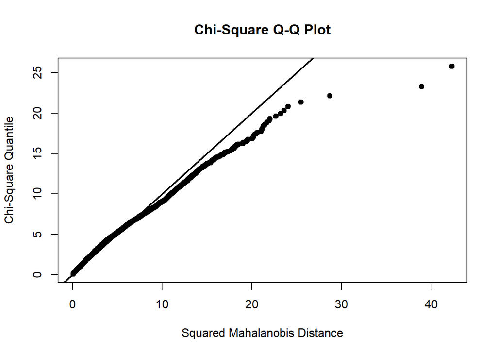

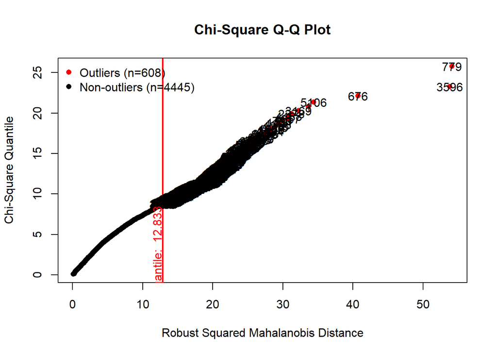

```
## $multivariateNormality
##              Test        Statistic               p value Result
## 1 Mardia Skewness 1101.16745567942 1.54400477446081e-208     NO
## 2 Mardia Kurtosis 16.2435580126329                     0     NO
## 3             MVN             <NA>                  <NA>     NO
##
## $univariateNormality
##                              Test  Variable Statistic   p value Normality
## 1 Lilliefors (Kolmogorov-Smirnov)  CSTRAT      0.0830  <0.001      NO
## 2 Lilliefors (Kolmogorov-Smirnov)   ELAB       0.1142  <0.001      NO
## 3 Lilliefors (Kolmogorov-Smirnov)   MEMO       0.1160  <0.001      NO
## 4 Lilliefors (Kolmogorov-Smirnov)  READING     0.0147  0.0148      NO
## 5 Lilliefors (Kolmogorov-Smirnov)   ESCS       0.0241  <0.001      NO
##
## $Descriptives
##            n         Mean    Std.Dev   Median      Min      Max     25th
## CSTRAT  5053  -0.04395397  1.1275654  -0.0411  -3.4531   2.5040  -0.5485
## ELAB    5053  -0.09066576  1.1123838   0.0385  -2.4098   2.7571  -0.6208
## MEMO    5053  -0.04299398  1.0978629   0.1036  -3.0191   2.6934  -0.5436
## READING 5053 500.32542054 94.1974810 501.8200 156.3800 772.4600 435.2300
## ESCS    5053   0.15773754  0.9203888   0.1816  -3.4232   2.8914  -0.4524
##             75th        Skew    Kurtosis
## CSTRAT    0.4861 -0.35552492  1.31315119
## ELAB      0.6034 -0.06026382  0.27118660
## MEMO      0.6832 -0.27496582  1.06348280
## READING 566.9400 -0.08480847 -0.34219415
## ESCS      0.8333 -0.24479949 -0.05784927
```

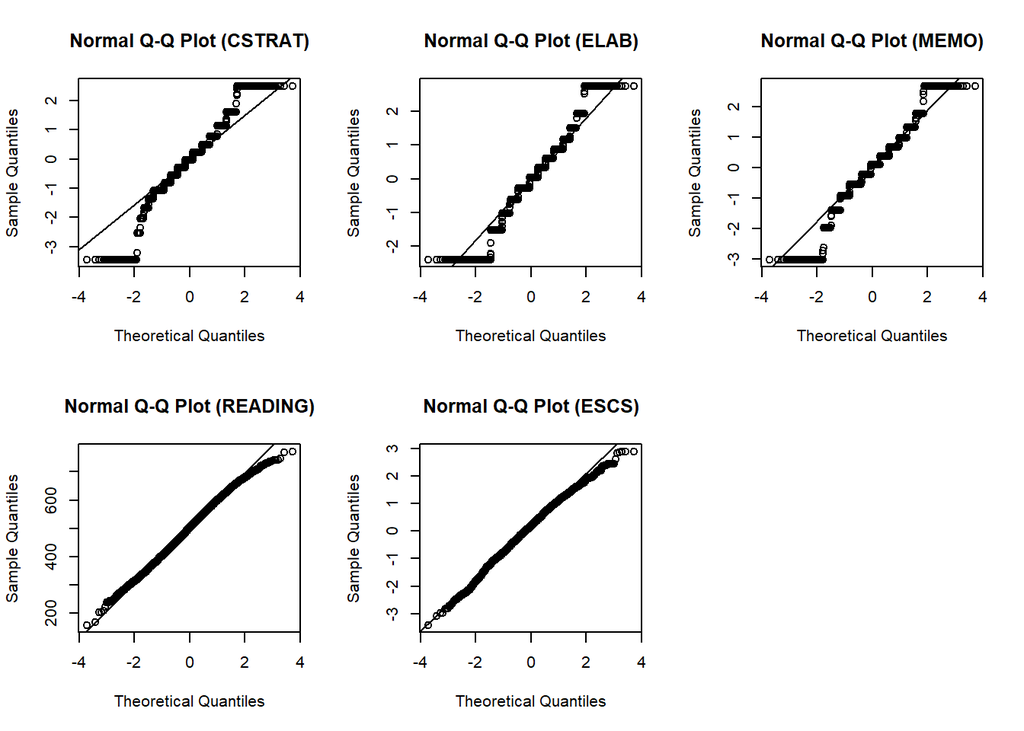

```r
# The MVN function performs a multivariate test for the continuous variables in this dataset:
mvn(PISA09.PathAnalysis[-c(6,7)], subset = NULL, mvnTest = c("mardia"),
    covariance = TRUE, tol = 1e-25, alpha = 0.5,
    scale = FALSE, desc = TRUE, transform = "none", R = 1000,
    univariateTest = c("Lillie"),
    univariatePlot = "qqplot", multivariatePlot = "qq",
    multivariateOutlierMethod = "quan", bc = FALSE, bcType = "rounded",
    showOutliers = FALSE, showNewData = FALSE)
```

The numerical output above shows the deviation from the univariate and multivariate normality assumptions. The univariate qq-plots in the bottom also show deviation from normality. Finally, Chi-square QQ-plots show significant amount of multivariate outliers in this dataset.

# Question 2

Estimate the model using ML. Compute all indirect and total effects in the model. Interpret the results.

```r
PISA.09.FirstModel <- '
# Regressions
#===================#
READING ~ A*MEMO + B*ELAB + C*CSTRAT
MEMO ~ D*ESCS + E*GENDER
ELAB ~ F*ESCS + G*GENDER + H*IMMIGR
CSTRAT ~ I*ESCS + J*GENDER + K*IMMIGR

# Mediation Analysis
#===================#
# Indirect effect of ESCS on READING through MEMO
DA := D*A
# Indirect effect of ESCS on READING through ELAB
FB := F*B
# Indirect effect of ESCS on READING through CSTRAT
IC := I*C
# Total indirect effect of ESCS on READING
DA_FB_IC := DA + FB + IC
#===================#
# Indirect effect of GENDER on READING through MEMO
EA := E*A
# Indirect effect of GENDER on READING through ELAB
GB := G*B
# Indirect effect of GENDER on READING through CSTRAT
JC := J*C
# Total indirect effect of GENDER on READING
EA_GB_JC := EA + GB + JC
#===================#
# Indirect effect of IMMIGR on READING through ELAB
HB := H*B
# Indirect effect of IMMIGR on READING through CSTRAT
KC := K*C
# Total indirect effect of IMMIGR on READING
HB_KC := HB + KC
'
# Perform path analysis
PISA.09.FirstModel.fit <- sem(PISA.09.FirstModel, data = PISA09.PathAnalysis, estimator = "ml")
```

```
## Warning in lav_data_full(data = data, group = group, cluster = cluster, :
## lavaan WARNING: some observed variances are (at least) a factor 1000 times
## larger than others; use varTable(fit) to investigate
```

The warning message asks for examining the variances of the variables:

```r
# Examine the variances of the variables with varTable() function from lavann:
varTable(PISA.09.FirstModel.fit)
```

```
##      name idx nobs    type exo user    mean      var nlev lnam
## 1 READING   4 5053 numeric   0    0 500.325 8873.165    0
## 2    MEMO   3 5053 numeric   0    0  -0.043    1.205    0
## 3    ELAB   2 5053 numeric   0    0  -0.091    1.237    0
## 4  CSTRAT   1 5053 numeric   0    0  -0.044    1.271    0
## 5    ESCS   5 5053 numeric   1    0   0.158    0.847    0
## 6  GENDER   6 5053 numeric   1    0   0.488    0.250    0
## 7  IMMIGR   7 5053 numeric   1    0   0.192    0.155    0
```

The variance table from the varTable() function above shows the variable READING needs to be scaled. However, scaling will not impact the fit parameters of the path model.

```r
# Generate summary of path analysis
summary(PISA.09.FirstModel.fit, fit.measures = TRUE, rsq = T)
```

```
## lavaan 0.6.17 ended normally after 1 iteration
##
##   Estimator                                         ML
##   Optimization method                           NLMINB
##   Number of model parameters                        15
##
##   Number of observations                          5053
##
## Model Test User Model:
##
##   Test statistic                              5585.354
##   Degrees of freedom                                 7
##   P-value (Chi-square)                           0.000
##
## Model Test Baseline Model:
##
##   Test statistic                              6845.608
##   Degrees of freedom                                18
##   P-value                                        0.000
##
## User Model versus Baseline Model:
##
##   Comparative Fit Index (CFI)                    0.183
##   Tucker-Lewis Index (TLI)                      -1.101
##
## Loglikelihood and Information Criteria:
##
##   Loglikelihood user model (H0)             -52631.946
##   Loglikelihood unrestricted model (H1)     -49839.269
##
##   Akaike (AIC)                              105293.891
##   Bayesian (BIC)                            105391.807
##   Sample-size adjusted Bayesian (SABIC)     105344.142
##
## Root Mean Square Error of Approximation:
##
##   RMSEA                                          0.397
##   90 Percent confidence interval - lower         0.388
##   90 Percent confidence interval - upper         0.406
##   P-value H_0: RMSEA <= 0.050                    0.000
```

[output cut: 42 more lines]

```
##     CSTRAT            0.061
##
## Defined Parameters:
##                    Estimate  Std.Err  z-value  P(>|z|)
##     DA               -0.916    0.442   -2.075    0.038
##     FB               -2.116    0.309   -6.859    0.000
##     IC               12.366    0.847   14.599    0.000
##     DA_FB_IC          9.333    1.003    9.308    0.000
##     EA               -5.945    0.848   -7.010    0.000
##     GB                0.447    0.472    0.948    0.343
##     JC               13.045    1.431    9.115    0.000
##     EA_GB_JC          7.547    1.729    4.366    0.000
##     HB               -2.515    0.652   -3.857    0.000
##     KC               10.829    1.874    5.777    0.000
##     HB_KC             8.314    1.984    4.191    0.000
```

```r
modindices(PISA.09.FirstModel.fit, standardized=TRUE, power=TRUE, delta=0.1,
           alpha=.05, high.power=.80) %>%
  arrange(desc(mi))
```

```
##        lhs op     rhs       mi      epc sepc.all delta          ncp power
## 1   CSTRAT  ~ READING 4029.389   -0.025   -2.317   0.1 6.612950e+04 1.000
## 2     MEMO  ~  CSTRAT 1985.352    0.624    0.641   0.1 5.096500e+01 1.000
## 3   CSTRAT  ~    MEMO 1966.556    0.624    0.608   0.1 5.043600e+01 1.000
## 4     MEMO ~~  CSTRAT 1966.556    0.744    0.624   0.1 3.552900e+01 1.000
## 5     ELAB ~~  CSTRAT 1767.623    0.714    0.591   0.1 3.466900e+01 1.000
## 6   CSTRAT  ~    ELAB 1767.623    0.585    0.577   0.1 5.168800e+01 1.000
## 7     ELAB  ~  CSTRAT 1767.623    0.598    0.606   0.1 4.939800e+01 1.000
## 8     MEMO  ~    ELAB 1116.603    0.464    0.470   0.1 5.195000e+01 1.000
## 9     MEMO ~~    ELAB 1103.579    0.564    0.467   0.1 3.473300e+01 1.000
## 10    ELAB  ~    MEMO 1103.579    0.473    0.467   0.1 4.930600e+01 1.000
## 11    MEMO  ~ READING  819.027    0.008    0.796   0.1 1.202311e+05 1.000
## 12 READING ~~  CSTRAT  617.041 -135.182   -1.425   0.1 0.000000e+00 0.050
## 13 READING  ~    ESCS  616.031   33.769    0.294   0.1 5.000000e-03 0.051
## 14    ESCS  ~ READING  560.835    0.003    0.397   0.1 4.694443e+05 1.000
```

[output cut: 69 more lines]

# Question 3

Provide and report on any evidence of the fit (or lack thereof) of the model.

Part A: Model identification Starting with the counting rule, there are total of s=7 variables, p=4 endogenous variables (READING, MEMOR, ELAB, and CSTRAT) and q=3 exogenous variables (ESCS, Gender, and Immigr). Therefore, we have 0.5*7(7+1)=28 element in the covariance matrix, and 10 variances and covariances of the exogenous variables (including disturbances). Therefore, the counting rule shows that t=28-21 = 7 degrees of freedom (as shown in the Model Test User Model), which is less than the number of elements in the covariance matrix and, therefore, the model is over identified.

The Loglikelihood and Information Criteria show that the model could be improved. The Akaike Information Criterion (AIC), the Bayesian Information Criterion (BIC), and the Sample-size adjusted Bayesian (SABIC) can only be used in comparing the fit with other models. The Root Mean Square Error of Approximation (RMSEA) value is 0.397, with a confidence interval ranging from 0.388 to 0.406. This is higher than the commonly accepted thresholds for a good fit (RMSEA <= 0.05) for a close fit and up to 0.08 for a reasonable fit. In this report, the p-value of the null hypothesis that RMSEA <= 0.050 is < 0.001 and for RMSEA >= 0.080 is 1.00 suggests that the RMSEA is truly above the reasonable limit of good model fit.

The Standardized Root Mean Square Residual (SRMR), which is a measure of the standardized difference between the observed and predicted correlations, has a value of 0.213. Generally, for SRMR, we need the value to be less than 0.08 for a good fit. Therefore, there is a significant discrepancies between the observed and model-implied covariances in this case.

The regression outputs show that READING score is negatively and significantly influenced by both MEMOrization and the index of ELABoration and positively, and also signficantly, by the index of Control STRATegies (CSTRAT). It is easy to notice that the regression coefficients of READINGS are larger than the rest of the coefficients in the regression due to the difference in the magnitude of the variances as noted in the output of the varTable() function above.

In this model, all the dependent variables are significantly influenced by their independent variables with the exception of the index of ELABoration, which is negatively influenced by the gender of female. However, that influence is not statistically significant.

The Variances output show the significance of the variances of the continuous variables. The R-square estimates, on the other hand, indicate the proportion of variance in each dependent variable explained by the independent variables in the model, with the variance in READING is 32.6% expalined by the dependent variables. For the Defined Parameters, all but one, GB, indirect effects are statistically significant, which indicates the true complexity of the model.

Finally, this model tells the complex story of the impact of socioeconomic factors on the READING scores through the students’ approaches to learning. Regardless of the poorly fitted model, the significance of the mediating effects shows the importance of considering these mediating variables for research and development. The model could be improved for a better fit by adding or removing variables or paths or by considering alternative theoretical structures.

# Question 4

Modify the model using the modification indices and expected parameter change statistics. Justify the modification on substantive grounds. (I recognize that this is not your data – make something up that is sensible).

The output of the modindices() function show the following parameters: 1- lhs (left-hand side): the dependent variables. 2- Operators of either regression (~) or variance-covariance (~~) 3- rhs (right-hand side): the independent or the covariant variables.  
4- mi (modification index): the expected change in the model’s chi-square for a freely estimated parameter. 5- epc (expected parameter change): the expected change in the freely estimated parameter. 6- sepc.all (standardized expected parameter change): the standardized EPC. 7- delta: minimum expected parameter change for which power is calculated.  
8- ncp (non-centrality parameter): indicates the deviation from the null hypothesis. 9- power: probability of correctly rejecting the false null hypothesis that the parameter is zero. A value of 1.00 indicates a very high chance of detecting a true effect. 10- decision: recommendation based on EPC and model fit. Refer to the slides on Model Modification and Statistical Power. Symbols with asterisks indicate a meaningful expected parameter change.

Following the procedures introduced in the course, a total of five models have been introduced in this lab. Following are the specifications of the all the models and their output:

```r
PISA.09.SecondModel <- '

# Regressions
READING ~ A*MEMO + B*ELAB + C*CSTRAT
MEMO ~ D*ESCS + E*GENDER + L*CSTRAT
ELAB ~ F*ESCS + G*GENDER + H*IMMIGR
CSTRAT ~ I*ESCS + J*GENDER + K*IMMIGR

# Mediation Analysis
#===================#
# Indirect effect of ESCS on READING through MEMO
DA := D*A
# Indirect effect of ESCS on READING through ELAB
FB := F*B
# Indirect effect of ESCS on READING through CSTRAT
IC := I*C
# Indirect effect of ESCS on READING through CSTRAT & MEMOR (new to second model)
ILA:= I*L*A
# Total indirect effect of ESCS on READING
DA_FB_IC := DA + FB + IC + ILA
#===================#
# Indirect effect of GENDER on READING through MEMO
EA := E*A
# Indirect effect of GENDER on READING through ELAB
GB := G*B
# Indirect effect of GENDER on READING through CSTRAT
JC := J*C
# Indirect effect of GENDER on READING through CSTRAT & MEMO (new to second model)
JLA := J*L*A
# Total indirect effect of GENDER on READING
EA_GB_JC := EA + GB + JC + JLA
#===================#
# Indirect effect of IMMIGR on READING through ELAB
HB := H*B
# Indirect effect of IMMIGR on READING through CSTRAT
KC := K*C
# Indirect effect of IMMIGR on READING through CSTRAT & MEMO (new to second model)
KLA := K*L*A
# Total indirect effect of IMMIGR on READING
HB_KC := HB + KC + KLA
'
# Perform path analysis
PISA.09.SecondModel.fit <- sem(PISA.09.SecondModel, data = PISA09.PathAnalysis, estimator = "ml")
# Generate summary of path analysis
summary(PISA.09.SecondModel.fit, fit.measures = TRUE, rsq = T)
```

```
## lavaan 0.6.17 ended normally after 1 iteration
##
##   Estimator                                         ML
##   Optimization method                           NLMINB
##   Number of model parameters                        16
##
##   Number of observations                          5053
##
## Model Test User Model:
##
##   Test statistic                              3063.548
##   Degrees of freedom                                 6
##   P-value (Chi-square)                           0.000
##
## Model Test Baseline Model:
##
##   Test statistic                              6845.608
##   Degrees of freedom                                18
##   P-value                                        0.000
##
## User Model versus Baseline Model:
##
##   Comparative Fit Index (CFI)                    0.552
##   Tucker-Lewis Index (TLI)                      -0.343
##
## Loglikelihood and Information Criteria:
##
##   Loglikelihood user model (H0)             -51371.043
##   Loglikelihood unrestricted model (H1)     -49839.269
##
##   Akaike (AIC)                              102774.086
##   Bayesian (BIC)                            102878.529
##   Sample-size adjusted Bayesian (SABIC)     102827.687
##
## Root Mean Square Error of Approximation:
##
##   RMSEA                                          0.318
##   90 Percent confidence interval - lower         0.308
##   90 Percent confidence interval - upper         0.327
##   P-value H_0: RMSEA <= 0.050                    0.000
```

[output cut: 46 more lines]

```
##                    Estimate  Std.Err  z-value  P(>|z|)
##     DA                3.069    0.387    7.927    0.000
##     FB               -2.116    0.309   -6.858    0.000
##     IC               12.366    0.879   14.063    0.000
##     ILA              -4.480    0.384  -11.664    0.000
##     DA_FB_IC          8.838    0.761   11.613    0.000
##     EA               -1.195    0.640   -1.867    0.062
##     GB                0.447    0.472    0.948    0.343
##     JC               13.045    1.453    8.980    0.000
##     JLA              -4.726    0.573   -8.249    0.000
##     EA_GB_JC          7.571    1.232    6.147    0.000
##     HB               -2.515    0.652   -3.857    0.000
##     KC               10.829    1.886    5.742    0.000
##     KLA              -3.923    0.709   -5.537    0.000
##     HB_KC             4.391    1.377    3.189    0.001
```

```r
modindices(PISA.09.SecondModel.fit, standardized=TRUE, power=TRUE, delta=0.1,
           alpha=.05, high.power=.80) %>%
  arrange(desc(mi))
```

```
##        lhs op     rhs       mi      epc sepc.all delta         ncp power
## 1   CSTRAT  ~ READING 2056.766   -0.026   -2.209   0.1   31178.885 1.000
## 2     ELAB ~~  CSTRAT 1767.623    0.714    0.591   0.1      34.669 1.000
## 3     ELAB  ~  CSTRAT 1767.623    0.598    0.606   0.1      49.398 1.000
## 4   CSTRAT  ~    ELAB 1767.623    0.585    0.577   0.1      51.688 1.000
## 5     ELAB  ~    MEMO 1106.486    0.474    0.468   0.1      49.177 1.000
## 6  READING  ~    ESCS  625.130   34.268    0.325   0.1       0.005 0.051
## 7  READING ~~  CSTRAT  617.947 -135.380   -1.427   0.1       0.000 0.050
## 8     ESCS  ~ READING  587.286    0.004    0.376   0.1  462213.559 1.000
## 9     ELAB  ~ READING  537.585    0.009    0.786   0.1   66125.367 1.000
## 10    MEMO  ~    ELAB   80.405    0.097    0.098   0.1      85.569 1.000
## 11    MEMO ~~    ELAB   79.675    0.118    0.126   0.1      57.212 1.000
## 12  GENDER  ~ READING   74.629    0.001    0.137   0.1 1499850.464 1.000
## 13 READING  ~  GENDER   67.931   20.319    0.105   0.1       0.002 0.050
## 14 READING  ~  IMMIGR   38.826  -19.370   -0.079   0.1       0.001 0.050
```

[output cut: 67 more lines]

```r
PISA.09.ThirdModel <- '

# Regressions
#===================#
READING ~ A*MEMO + B*ELAB + C*CSTRAT
MEMO ~ D*ESCS + E*GENDER + L*CSTRAT
ELAB ~ F*ESCS + G*GENDER + H*IMMIGR + M*CSTRAT
CSTRAT ~ I*ESCS + J*GENDER + K*IMMIGR

# Mediation Analysis
#===================#
# Indirect effect of ESCS on READING through MEMO
DA := D*A
# Indirect effect of ESCS on READING through ELAB
FB := F*B
# Indirect effect of ESCS on READING through CSTRAT
IC := I*C
# Indirect effect of ESCS on READING through CSTRAT & MEMOR
ILA := I*L*A
# Indirect effect of ESCS on READING through CSTRAT & ELAB (new to third model)
IMB := I*M*B
# Total indirect effect of ESCS on READING
DA_FB_IC_ILA_IMB := DA + FB + IC + ILA + IMB
#===================#
# Indirect effect of GENDER on READING through MEMO
EA := E*A
# Indirect effect of GENDER on READING through ELAB
GB := G*B
# Indirect effect of GENDER on READING through CSTRAT
JC := J*C
# Indirect effect of GENDER on READING through CSTRAT & MEMO
JLA := J*L*A
# Indirect effect of GENDER on READING through CSTRAT & ELAB (new to third model)
JMB := J*M*B
# Total indirect effect of GENDER on READING
EA_GB_JC_JLA_JMB := EA + GB + JC + JLA + JMB
#===================#
# Indirect effect of IMMIGR on READING through ELAB
HB := H*B
# Indirect effect of IMMIGR on READING through CSTRAT
KC := K*C
# Indirect effect of IMMIGR on READING through CSTRAT & MEMO
KLA := K*L*A
# Indirect effect of IMMIGR on READING through CSTRAT & ELAB (new to third model)
KMB := K*M*B
# Total indirect effect of IMMIGR on READING
HB_KC_KLA_KMB := HB + KC + KLA + KMB
'
#==============================================================================#
# Generate summary of path analysis
PISA.09.ThirdModel.fit <- sem(PISA.09.ThirdModel, data = PISA09.PathAnalysis, estimator = "ml")
summary(PISA.09.ThirdModel.fit, fit.measures = TRUE, rsq = T)
```

```
## lavaan 0.6.17 ended normally after 1 iteration
##
##   Estimator                                         ML
##   Optimization method                           NLMINB
##   Number of model parameters                        17
##
##   Number of observations                          5053
##
## Model Test User Model:
##
##   Test statistic                               888.228
##   Degrees of freedom                                 5
##   P-value (Chi-square)                           0.000
##
## Model Test Baseline Model:
##
##   Test statistic                              6845.608
##   Degrees of freedom                                18
##   P-value                                        0.000
##
## User Model versus Baseline Model:
##
##   Comparative Fit Index (CFI)                    0.871
##   Tucker-Lewis Index (TLI)                       0.534
##
## Loglikelihood and Information Criteria:
##
##   Loglikelihood user model (H0)             -50283.383
##   Loglikelihood unrestricted model (H1)     -49839.269
##
##   Akaike (AIC)                              100600.766
##   Bayesian (BIC)                            100711.737
##   Sample-size adjusted Bayesian (SABIC)     100657.717
##
## Root Mean Square Error of Approximation:
##
##   RMSEA                                          0.187
##   90 Percent confidence interval - lower         0.177
##   90 Percent confidence interval - upper         0.197
##   P-value H_0: RMSEA <= 0.050                    0.000
```

[output cut: 50 more lines]

```
##     IC               12.366    0.905   13.656    0.000
##     ILA              -4.480    0.384  -11.664    0.000
##     IMB              -2.465    0.277   -8.912    0.000
##     DA_FB_IC_ILA_I    8.838    0.631   14.001    0.000
##     EA               -1.195    0.640   -1.867    0.062
##     GB                3.048    0.471    6.471    0.000
##     JC               13.045    1.470    8.871    0.000
##     JLA              -4.726    0.573   -8.250    0.000
##     JMB              -2.601    0.367   -7.083    0.000
##     EA_GB_JC_JLA_J    7.571    1.045    7.247    0.000
##     HB               -0.356    0.507   -0.701    0.483
##     KC               10.829    1.895    5.714    0.000
##     KLA              -3.923    0.709   -5.537    0.000
##     KMB              -2.159    0.420   -5.139    0.000
##     HB_KC_KLA_KMB     4.391    0.995    4.414    0.000
```

```r
#==============================================================================#
modindices(PISA.09.ThirdModel.fit, standardized=TRUE, power=TRUE, delta=0.1,
           alpha=.05, high.power=.80) %>%
  arrange(desc(mi))
```

```
##        lhs op     rhs      mi      epc sepc.all delta         ncp power
## 1  READING  ~    ESCS 619.743   33.973    0.334   0.1       0.005 0.051
## 2  READING ~~  CSTRAT 616.618 -135.089   -1.424   0.1       0.000 0.050
## 3   CSTRAT  ~ READING 607.955   -0.018   -1.472   0.1   19373.974 1.000
## 4     ESCS  ~ READING 580.759    0.004    0.359   0.1  467407.739 1.000
## 5     MEMO  ~    ELAB 124.045    0.150    0.152   0.1      55.465 1.000
## 6     MEMO ~~    ELAB 123.842    0.119    0.157   0.1      87.994 1.000
## 7     ELAB  ~    MEMO 123.842    0.164    0.162   0.1      46.038 1.000
## 8   GENDER  ~ READING  75.537    0.001    0.134   0.1 1481811.511 1.000
## 9  READING  ~  GENDER  68.748   20.564    0.110   0.1       0.002 0.050
## 10 READING  ~  IMMIGR  38.813  -19.364   -0.081   0.1       0.001 0.050
## 11    MEMO  ~ READING  30.372    0.004    0.324   0.1   21129.265 1.000
## 12    ELAB  ~ READING  21.522   -0.002   -0.200   0.1   38224.267 1.000
## 13  GENDER  ~    MEMO   1.566   -1.620   -3.557   0.1       0.006 0.051
## 14    ESCS  ~    MEMO   1.010    0.051    0.061   0.1       3.846 0.501
```

[output cut: 59 more lines]

```r
PISA.09.FourthModel <- '

# Regressions
#===================#
READING ~ A*MEMO + B*ELAB + C*CSTRAT
MEMO ~ D*ESCS + E*GENDER + L*CSTRAT + N*ELAB
ELAB ~ F*ESCS + G*GENDER + H*IMMIGR + M*CSTRAT
CSTRAT ~ I*ESCS + J*GENDER + K*IMMIGR

# Mediation Analysis
#===================#
# Indirect effect of ESCS on READING through MEMO
DA := D*A
# Indirect effect of ESCS on READING through ELAB
FB := F*B
# Indirect effect of ESCS on READING through ELAB & MEMOR
FNA := F*N*A
# Indirect effect of ESCS on READING through CSTRAT
IC := I*C
# Indirect effect of ESCS on READING through CSTRAT & MEMOR
ILA := I*L*A
# Indirect effect of ESCS on READING through CSTRAT & ELAB
IMB := I*M*B
# Indirect effect of ESCS on READING through CSTRAT & ELAB & MEMOR (new to the fourth model)
IMNA := I*M*N*A
# Total indirect effect of ESCS on READING
DA_FB_IC_ILA_IMB := DA + FB + IC + ILA + IMB + FNA + IMNA
#===================#
# Indirect effect of GENDER on READING through MEMO
EA := E*A
# Indirect effect of GENDER on READING through ELAB
GB := G*B
# Indirect effect of GENDER on READING through CSTRAT
JC := J*C
# Indirect effect of GENDER on READING through CSTRAT & MEMO
JLA := J*L*A
# Indirect effect of GENDER on READING through CSTRAT & ELAB
JMB := J*M*B
# Indirect effect of GENDER on READING through CSTRAT & ELAB & MEMO (new to the fourth model)
JMNA := J*M*N*A
# Total indirect effect of GENDER on READING
EA_GB_JC_JLA_JMB := EA + GB + JC + JLA + JMB + JMNA
#===================#
# Indirect effect of IMMIGR on READING through ELAB
HB := H*B
# Indirect effect of IMMIGR on READING through CSTRAT
KC := K*C
# Indirect effect of IMMIGR on READING through CSTRAT & MEMO
KLA := K*L*A
# Indirect effect of IMMIGR on READING through CSTRAT & ELAB
KMB := K*M*B
# Indirect effect of IMMIGR on READING through CSTRAT & ELAB & MEMO (new to the fourth model)
KMNA := K*M*N*A
# Total indirect effect of IMMIGR on READING
HB_KC_KLA_KMB := HB + KC + KLA + KMB + KMNA
'
#==============================================================================#
# Generate summary of path analysis
PISA.09.FourthModel.fit <- sem(PISA.09.FourthModel, data = PISA09.PathAnalysis, estimator = "ml")
summary(PISA.09.FourthModel.fit, fit.measures = TRUE, rsq = T)
```

```
## lavaan 0.6.17 ended normally after 1 iteration
##
##   Estimator                                         ML
##   Optimization method                           NLMINB
##   Number of model parameters                        18
##
##   Number of observations                          5053
##
## Model Test User Model:
##
##   Test statistic                               762.636
##   Degrees of freedom                                 4
##   P-value (Chi-square)                           0.000
##
## Model Test Baseline Model:
##
##   Test statistic                              6845.608
##   Degrees of freedom                                18
##   P-value                                        0.000
##
## User Model versus Baseline Model:
##
##   Comparative Fit Index (CFI)                    0.889
##   Tucker-Lewis Index (TLI)                       0.500
##
## Loglikelihood and Information Criteria:
##
##   Loglikelihood user model (H0)             -50220.586
##   Loglikelihood unrestricted model (H1)     -49839.269
##
##   Akaike (AIC)                              100477.173
##   Bayesian (BIC)                            100594.672
##   Sample-size adjusted Bayesian (SABIC)     100537.474
##
## Root Mean Square Error of Approximation:
##
##   RMSEA                                          0.194
##   90 Percent confidence interval - lower         0.182
##   90 Percent confidence interval - upper         0.205
##   P-value H_0: RMSEA <= 0.050                    0.000
```

[output cut: 55 more lines]

```
##     IMNA             -0.642    0.080   -8.072    0.000
##     DA_FB_IC_ILA_I    8.827    0.650   13.584    0.000
##     EA               -1.989    0.642   -3.098    0.002
##     GB                3.048    0.473    6.444    0.000
##     JC               13.045    1.465    8.903    0.000
##     JLA              -4.048    0.497   -8.141    0.000
##     JMB              -2.601    0.369   -7.048    0.000
##     JMNA             -0.677    0.102   -6.639    0.000
##     EA_GB_JC_JLA_J    6.778    1.052    6.443    0.000
##     HB               -0.356    0.507   -0.701    0.483
##     KC               10.829    1.893    5.722    0.000
##     KLA              -3.360    0.611   -5.504    0.000
##     KMB              -2.159    0.421   -5.126    0.000
##     KMNA             -0.562    0.113   -4.962    0.000
##     HB_KC_KLA_KMB     4.391    0.995    4.414    0.000
```

```r
#==============================================================================#
modindices(PISA.09.FourthModel.fit, standardized=TRUE, power=TRUE, delta=0.1,
           alpha=.05, high.power=.80) %>%
  arrange(desc(mi))
```

```
##        lhs op     rhs      mi      epc sepc.all delta         ncp power
## 1  READING  ~    ESCS 619.451   33.957    0.332   0.1       0.005 0.051
## 2  READING ~~  CSTRAT 615.573 -134.860   -1.421   0.1       0.000 0.050
## 3   CSTRAT  ~ READING 607.506   -0.018   -1.478   0.1   19403.138 1.000
## 4     ESCS  ~ READING 581.031    0.004    0.361   0.1  467521.482 1.000
## 5     MEMO  ~ READING 409.220    0.021    1.824   0.1    9051.432 1.000
## 6     ELAB  ~ READING 189.499    0.017    1.478   0.1    6217.626 1.000
## 7   GENDER  ~ READING  75.636    0.001    0.135   0.1 1479791.042 1.000
## 8  READING  ~  GENDER  68.847   20.593    0.109   0.1       0.002 0.050
## 9  READING  ~  IMMIGR  38.811  -19.363   -0.081   0.1       0.001 0.050
## 10  GENDER  ~    MEMO   2.036   -2.374   -5.214   0.1       0.004 0.050
## 11    ESCS  ~    MEMO   0.811    0.046    0.055   0.1       3.769 0.493
## 12    MEMO ~~    ELAB   0.769   -0.934   -1.248   0.1       0.009 0.051
## 13  CSTRAT  ~    MEMO   0.769   -0.196   -0.191   0.1       0.200 0.073
## 14    MEMO ~~  CSTRAT   0.769   -0.138   -0.151   0.1       0.401 0.097
```

[output cut: 53 more lines]

```r
PISA.09.FifthModel <- '

# Regressions
#===================#
READING ~ A*MEMO + B*ELAB + C*CSTRAT + O*ESCS + P*GENDER + Q*IMMIGR
#New to the Fifth model O*ESCS + P*GENDER + Q*IMMIGR
MEMO ~ D*ESCS + E*GENDER + L*CSTRAT + N*ELAB
ELAB ~ F*ESCS + G*GENDER + H*IMMIGR + M*CSTRAT
CSTRAT ~ I*ESCS + J*GENDER + K*IMMIGR

# Mediation Analysis
#===================#
# Indirect effect of ESCS on READING through MEMO
DA := D*A
# Indirect effect of ESCS on READING through ELAB
FB := F*B
# Indirect effect of ESCS on READING through ELAB & MEMOR
FNA := F*N*A
# Indirect effect of ESCS on READING through CSTRAT
IC := I*C
# Indirect effect of ESCS on READING through CSTRAT & MEMOR
ILA := I*L*A
# Indirect effect of ESCS on READING through CSTRAT & ELAB
IMB := I*M*B
# Indirect effect of ESCS on READING through CSTRAT & ELAB & MEMOR
IMNA := I*M*N*A
# Total indirect effect of ESCS on READING
DA_FB_IC_ILA_IMB := DA + FB + IC + ILA + IMB + FNA + IMNA
#===================#
# Indirect effect of GENDER on READING through MEMO
EA := E*A
# Indirect effect of GENDER on READING through ELAB
GB := G*B
# Indirect effect of GENDER on READING through CSTRAT
JC := J*C
# Indirect effect of GENDER on READING through CSTRAT & MEMO
JLA := J*L*A
# Indirect effect of GENDER on READING through CSTRAT & ELAB
JMB := J*M*B
# Indirect effect of GENDER on READING through CSTRAT & ELAB & MEMO
JMNA := J*M*N*A
# Total indirect effect of GENDER on READING
EA_GB_JC_JLA_JMB := EA + GB + JC + JLA + JMB + JMNA
#===================#
# Indirect effect of IMMIGR on READING through ELAB
HB := H*B
# Indirect effect of IMMIGR on READING through CSTRAT
KC := K*C
# Indirect effect of IMMIGR on READING through CSTRAT & MEMO
KLA := K*L*A
# Indirect effect of IMMIGR on READING through CSTRAT & ELAB
KMB := K*M*B
# Indirect effect of IMMIGR on READING through CSTRAT & ELAB & MEMO
KMNA := K*M*N*A
# Total indirect effect of IMMIGR on READING
HB_KC_KLA_KMB := HB + KC + KLA + KMB + KMNA
'
#==============================================================================#
# Generate summary of path analysis
PISA.09.FifthModel.fit <- sem(PISA.09.FifthModel, data = PISA09.PathAnalysis, estimator = "ml")
summary(PISA.09.FifthModel.fit, fit.measures = TRUE, rsq = T)
```

```
## lavaan 0.6.17 ended normally after 1 iteration
##
##   Estimator                                         ML
##   Optimization method                           NLMINB
##   Number of model parameters                        21
##
##   Number of observations                          5053
##
## Model Test User Model:
##
##   Test statistic                                 0.769
##   Degrees of freedom                                 1
##   P-value (Chi-square)                           0.381
##
## Model Test Baseline Model:
##
##   Test statistic                              6845.608
##   Degrees of freedom                                18
##   P-value                                        0.000
##
## User Model versus Baseline Model:
##
##   Comparative Fit Index (CFI)                    1.000
##   Tucker-Lewis Index (TLI)                       1.001
##
## Loglikelihood and Information Criteria:
##
##   Loglikelihood user model (H0)             -49839.653
##   Loglikelihood unrestricted model (H1)     -49839.269
##
##   Akaike (AIC)                               99721.306
##   Bayesian (BIC)                             99858.388
##   Sample-size adjusted Bayesian (SABIC)      99791.657
##
## Root Mean Square Error of Approximation:
##
##   RMSEA                                          0.000
##   90 Percent confidence interval - lower         0.000
##   90 Percent confidence interval - upper         0.035
##   P-value H_0: RMSEA <= 0.050                    0.996
```

[output cut: 58 more lines]

```
##     IMNA             -0.550    0.069   -7.925    0.000
##     DA_FB_IC_ILA_I    6.497    0.546   11.892    0.000
##     EA               -1.703    0.551   -3.090    0.002
##     GB                2.730    0.430    6.350    0.000
##     JC               10.139    1.165    8.700    0.000
##     JLA              -3.467    0.434   -7.990    0.000
##     JMB              -2.329    0.336   -6.925    0.000
##     JMNA             -0.580    0.088   -6.556    0.000
##     EA_GB_JC_JLA_J    4.789    0.861    5.562    0.000
##     HB               -0.319    0.455   -0.701    0.483
##     KC                8.417    1.485    5.667    0.000
##     KLA              -2.878    0.527   -5.456    0.000
##     KMB              -1.934    0.381   -5.078    0.000
##     KMNA             -0.482    0.098   -4.927    0.000
##     HB_KC_KLA_KMB     2.804    0.746    3.759    0.000
```

```r
#==============================================================================#
modindices(PISA.09.FifthModel.fit, standardized=TRUE, power=TRUE, delta=0.1,
           alpha=.05, high.power=.80) %>%
  arrange(desc(mi))
```

```
##       lhs op     rhs    mi    epc sepc.all delta          ncp power decision
## 1  GENDER  ~    MEMO 2.036 -2.374   -5.214   0.1 4.000000e-03 0.050      (i)
## 2    ESCS  ~    MEMO 0.811  0.046    0.055   0.1 3.769000e+00 0.493      (i)
## 3    ELAB  ~ READING 0.769  0.059    4.965   0.1 2.235000e+00 0.321      (i)
## 4    MEMO ~~    ELAB 0.769 -0.934   -1.248   0.1 9.000000e-03 0.051      (i)
## 5    MEMO  ~ READING 0.769  0.006    0.544   0.1 1.913900e+02 1.000     (nm)
## 6  CSTRAT  ~    MEMO 0.769 -0.196   -0.191   0.1 2.000000e-01 0.073      (i)
## 7    MEMO ~~  CSTRAT 0.769 -0.138   -0.151   0.1 4.010000e-01 0.097      (i)
## 8    MEMO  ~  IMMIGR 0.769  0.028    0.010   0.1 1.005800e+01 0.887     (nm)
## 9    ELAB  ~    MEMO 0.769 -1.324   -1.307   0.1 4.000000e-03 0.051      (i)
## 10 CSTRAT  ~ READING 0.769  0.009    0.726   0.1 1.018570e+02 1.000     (nm)
## 11 IMMIGR  ~    MEMO 0.766  0.006    0.015   0.1 2.512260e+02 1.000     (nm)
## 12 IMMIGR  ~ READING 0.524  0.000   -0.040   0.1 1.871480e+05 1.000     (nm)
## 13   ESCS  ~ READING 0.459 -0.001   -0.119   0.1 3.396077e+03 1.000     (nm)
## 14 GENDER  ~ READING 0.202  0.010    1.966   0.1 1.856400e+01 0.991     (nm)
## 15   ESCS  ~    ELAB 0.000  0.000    0.000   0.1 9.000000e-03 0.051      (i)
## 16   ESCS  ~  CSTRAT 0.000  0.000    0.000   0.1 2.000000e-02 0.052      (i)
## 17 GENDER  ~    ELAB 0.000  0.000    0.000   0.1 2.000000e-03 0.050      (i)
## 18 IMMIGR  ~  CSTRAT 0.000  0.000    0.000   0.1 1.570000e-01 0.068      (i)
## 19 IMMIGR  ~    ELAB 0.000  0.000    0.000   0.1 7.300000e-02 0.058      (i)
## 20 GENDER  ~  CSTRAT 0.000  0.000    0.000   0.1 4.000000e-03 0.050      (i)
## 21 GENDER  ~  IMMIGR 0.000  0.000    0.000   0.1 5.800000e-02 0.057      (i)
## 22   ESCS ~~  GENDER 0.000  0.000       NA   0.1 5.000000e-02 0.056      (i)
## 23 IMMIGR  ~  GENDER 0.000  0.000    0.000   0.1 1.980000e-01 0.073      (i)
## 24   ESCS ~~    ESCS 0.000  0.000    0.000   0.1 1.140000e-01 0.063      (i)
## 25 GENDER ~~  IMMIGR 0.000  0.000       NA   0.1 2.902000e+00 0.399      (i)
## 26 IMMIGR  ~    ESCS 0.000  0.000    0.000   0.1 4.684000e+00 0.581      (i)
## 27   ESCS  ~  GENDER 0.000  0.000    0.000   0.1 2.959986e+29 1.000     (nm)
## 28   ESCS ~~  IMMIGR 0.000  0.000       NA   0.1 6.453000e+00 0.719      (i)
## 29   ESCS  ~  IMMIGR 0.000  0.000    0.000   0.1          NaN   NaN
```

# Question 5

Choose a final model based on the AIC.

https://github.com/alibahkali/EDPSY960/blob/main/FifthModel.jpg